# Virtualization - Linux Container on CentOS

# Setup

### Objective

- Install and spin a LXC container on CentOS 7

### Pre-requisites

#### CentOS image

In this article, we used CentOS 7 64 bits - can be downloaded as a VirtualBox image from https://www.osboxes.org/centos/.

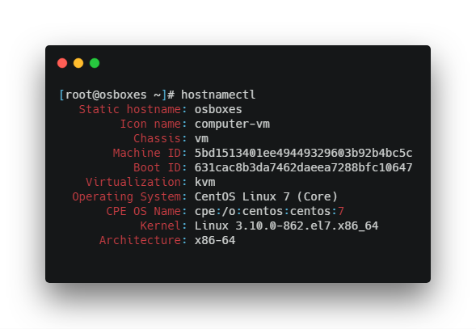

#### SELinux

**SELinux** must be disabled with

```r
  setenforce 0
```

**SELinux** prevents some files like `passwd` to be updated. Not disabling it could generate errors during the container creation and a `passwd authentication token manipulation error` error when updating passwords.

#### EPEL

You will need to install the EPEL repository (Exta Package For Entreprise Linux).

```r
yum install -y epel-release
```

### Install LXC

- Now, you are ready to install LXC and its templates with:

```r
yum install -y lxc lxc-templates debootstrap perl libcap-devel libcgroup wget bridge-utils x-extra libvirt`
```

[figure not shown]

- Once installation is complete, start and enable the **LXC.service**.

```r
 systemctl start lxc
 systemctl enable lxc
```

# Create a LXC container

### Explore LXC

You can explore the LXC directory with following commands:

- `ls -lrt /usr/share/lxc/`
- `ls -lrt /usr/share/lxc/templates/` where the available templates are stored

### Create your container

- Create you first container by running `lxc-create -n centos_vm1 -t centos`

```r
 lxc-create -n centos_vm1 -t centos
```

- Successful creation will show this.

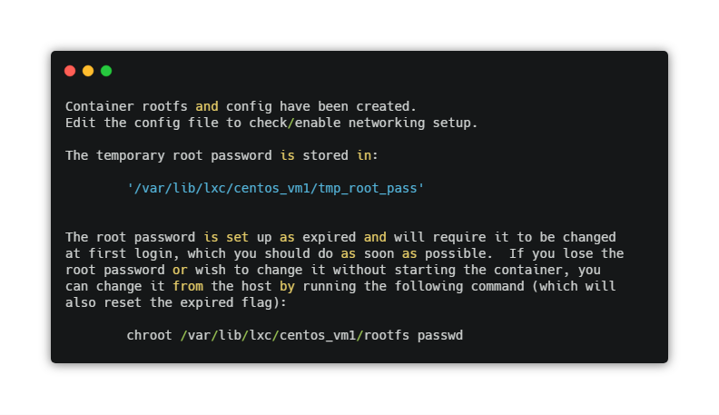

- List the containers created with `lxc-ls --fancy`
- To update the password, run the

```r
 chroot /var/lib/lxc/centos_vm1/rootfs passwd
```

### Start your container

- Start your Centos container.

```r
  lxc-start -n centos_vm1 -d
```

`-d` will avoid being prompted the username/password fields.

- You can check the `STATE` with `lxc-ls --fancy`

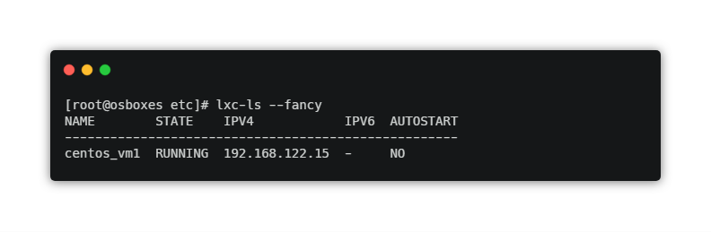

- Now you are ready to log into your Centos container with `lxc-attach`

```r
  lxc-attach -n centos_vm1
```

[figure not shown]

# Use your LXC container

### LXC commands

- `lxc-clone`
- `lxc-destroy`

### Other commands

- You can then run usual commands on the container or install new packages.

```r
ip a s
1: lo: <LOOPBACK,UP,LOWER_UP> mtu 65536 qdisc noqueue state UNKNOWN group default qlen 1000
    link/loopback 00:00:00:00:00:00 brd 00:00:00:00:00:00
    inet 127.0.0.1/8 scope host lo
       valid_lft forever preferred_lft forever
    inet6 ::1/128 scope host
       valid_lft forever preferred_lft forever
6: eth0@if7: <BROADCAST,MULTICAST,UP,LOWER_UP> mtu 1500 qdisc noqueue state UP group default qlen 1000
    link/ether fe:5b:01:7a:f3:2c brd ff:ff:ff:ff:ff:ff link-netnsid 0
    inet 192.168.122.15/24 brd 192.168.122.255 scope global dynamic eth0
       valid_lft 3582sec preferred_lft 3582sec
    inet6 fe80::fc5b:1ff:fe7a:f32c/64 scope link
       valid_lft forever preferred_lft forever
```

```r
yum install -y nmap
```

- `exit` command will allow you to exit from the container
- `shutdown -r now` will restart the container

A work by [ilsa](http://www.itdataops.com)

*joassouramou@gmail.com*